# Child Mortality and Primary Education Access in 2020

## Overview

This report compares two Gapminder indicators for **2020**:

- **Child mortality (0–5 year olds dying per 1,000 born)**
- **Children out of school (primary)**

Both datasets are subset to 2020, mapped globally, and compared in a scatterplot.

## Child mortality in 2020

In 2020, **194** countries and territories have child mortality data. Values range from **1.9** to **114.4** deaths per 1,000 live births.

[figure not shown]

## Children out of school (primary) in 2020

In 2020, **141** countries report counts of primary-age children out of school. Reported values range from **11** to **3,989,763** children.

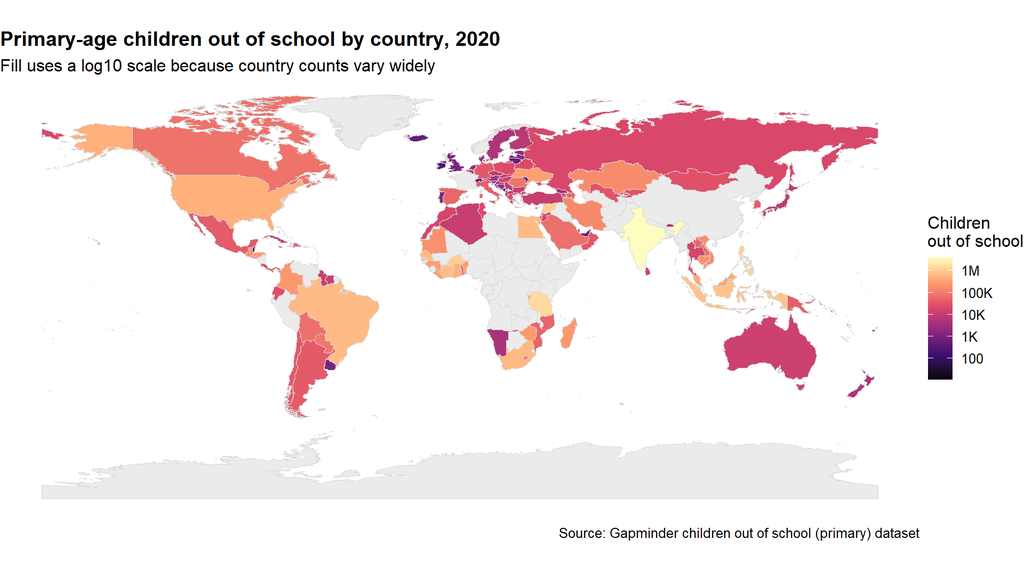

## Relationship between the two indicators in 2020

The scatterplot below includes the **141** countries with non-missing values for both indicators in 2020.

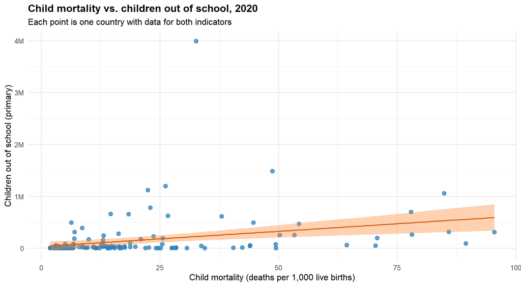

## Interpretation

Across countries with complete 2020 data, child mortality and the number of primary-age children out of school show a **moderate positive association** (Pearson *r* = **0.29**). Countries with higher under-5 mortality tend to report more children out of school, but the relationship is far from perfect.

Several patterns help explain this:

- **Shared drivers of disadvantage.** Higher child mortality and larger out-of-school populations both reflect broader constraints—poverty, weak health systems, and limited education infrastructure—that often occur together in the same countries, especially in parts of sub-Saharan Africa and South Asia visible on the maps.
- **Population size matters for counts.** The out-of-school indicator is an absolute count, not a rate. Large countries such as India can appear high on the y-axis even when mortality is moderate, which adds scatter and weakens a simple linear fit (slope ≈ **5,827** additional children out of school per one-unit increase in mortality; *p* **< 0.001**).
- **Many high-income countries cluster differently.** Several countries combine low mortality with relatively small out-of-school counts, while outliers with high mortality but moderate counts suggest that education access can diverge from health outcomes within the same mortality band.

Overall, the maps and scatterplot suggest that **health and primary-school access are related dimensions of child well-being**, but they are not interchangeable: reducing mortality alone would not automatically eliminate out-of-school children, and vice versa.

## Reflection

*[ This was my first experience using Cursor to generate a complete R Markdown report with an AI agent. I found it surprisingly efficient for exploring datasets, generating code, and creating visualizations automatically. The easiest part was having the agent perform repetitive coding tasks, while the most challenging part was understanding how the agent interacted with R and managing the permissions required to execute commands. This exercise showed me that AI can accelerate data analysis workflows, but human oversight remains important to verify results and ensure that the generated output is appropriate for the intended analysis.]*